# E-commerce market data analysis

### Table of Contents:

- 1. Introduction
  - 1.1. Project description
  - 1.2. Data
    - 1.2.1. e-commerce data
    - 1.2.2. Socio-economic data
    - 1.2.3. Colors data
  - 1.3. Data cleaning and manipulation
- 2. Exploratory data analysis
  - 2.1. Number of observations by country
  - 2.2. Number and total sales by country
  - 2.4. Unique customers by country
  - 2.5. Average item price by country
- 3. Market Analysis
  - 3.1. Relationship between GDP and expenditure
  - 3.2. Quantity trends by type of sale
  - 3.3. Price trends by type of sale
- 4. Product analysis
  - 4.1. Most popular colors
  - 4.2. Most popular and most returned items
- 5. Conclusions

# 1. Introduction

### 1.1. Project description

In this project we analyse the **transactions of an e-commerce platform** occurring over the years 2010 and 2011 to extract **customer and market insights**. Our goal is to design and obtain **Key Performance Indicators** (KPIs) to identify room for improvement in the platform performance. Some of the **questions** we will address include:

- *Which country expends the most in aggregate?*
- *Is there a relationship between a country's GDP and its purchases on the platform?*
- *Which products are most popular in the platform?*

The analysis will be conducted following **three steps**:

1. Loading three datasets
2. Data cleaning and manipulation
3. Data Analysis:
   - Exploratory Data Analysis (EDA) to find salient patterns and infer relationships between data elements.
   - Market and product analysis.

For the analysis, we employed the following **packages**:

- **NumPy**
- **Pandas**
- **Matplotlib**
- **Seaborn**

### 1.2. Data

#### 1.2.1. e-commerce data

We use an open-source [dataset](https://archive-beta.ics.uci.edu/ml/datasets/online+retail) containing actual e-commerce transactions occurring between 01/12/2010 and 09/12/2011 for a UK-based online retailer. The dataset consists in **541,909 observations**, specifically **38 countries** and **4,373 unique customers**. The dataset includes the following variables:

- **InvoiceNo**: Invoice number. Nominal, a 6-digit integral number uniquely assigned to each transaction. Invoice numbers starting with the letter 'C' represent returned items, which are matched with a negative value in the "Quantity" column.
- **StockCode**: Product (item) code. Nominal, a 5-digit integral number uniquely assigned to each distinct product.
- **Description**: Product (item) name. Nominal.
- **Quantity**: The quantities of each product (item) per transaction. Numeric.
- **InvoiceDate**: Invice Date and time. Numeric, the day and time when each transaction was generated.
- **UnitPrice**: Unit price. Numeric, Product price per unit in sterling.
- **CustomerID**: Customer number. Nominal, a 5-digit integral number uniquely assigned to each customer.
- **Country**: Country name. Nominal, the name of the country where each customer resides.

#### 1.2.2. Socio-economic data

We use data on **GDP per capita** from the [World Bank](https://data.worldbank.org/indicator/NY.GDP.PCAP.CD).

#### 1.2.3. Colors data

We use a [dataset](https://data.world/dilumr/color-names) on color name and hex color codes to build the variable Hex color code.

### 1.3. Data cleaning and manipulation

- For the purpose of this analysis, all monetary values were converted to EUR.
- Missing values in "CustomerID" were removed
- The dataset was split into two:
  1. "**cust_pos**" for positive values in "Quantity" (representing orders), consisting in 397,924 observations.
  2. "**returns**" for negative values in "Quantity" (representing returns), consisting in 55 observations.
- The following variables on **total and average purchases** (by country and by unique customer) were created:
  - "tot_purch_country"
  - "tot_exp_country"
  - "unique_cust_per_country"
  - "tot_purch_country_per_cust"
  - "tot_exp_country_per_cust"
  - "tot_exp_cust"
  - "avg_purch_country"
  - "avg_exp_country"
  - "avg_cust_per_country"
  - "avg_purch_country_per_cust"
  - "avg_exp_country_per_cust"
- The datasets "cust_pos" and "gdp" were **merged** on their common column "Country" to retrieve information on GDP per capita for the year 2011. The resulting dataset is called "**cust_selected_gdp**".
- The following binary variables were created:
  - "**EU Membership**": splitting countries into "EU" and "Non-EU". Please note that at the time of the data collection the UK was still part of the EU.
  - "**Sale Type**": for the purpose of this analysis, we split orders into "Retail", for values smaller or equal to 15 in "Quantity", and "Wholesale" for values greater than 15.

## 2. Exploratory data analysis

For the following analysis, we focused on markets with a **sales volume above 10,000 EUR**. The analytical sample is thus reduced to **385,626 observations**, covering **13 countries**.

## 2.1. Number of observations by country

The first graph shows the number of observations by country. After an initial glimpse, it is evident that observations are not distributed equally among countries, with the **UK being largely over-represented**. It is important to bear this inherent bias in mind when interpreting the results of the analysis. Due to the fact that at the time of the data collection the UK was still a member of the EU, EU countries are also over-represented in the second graph.

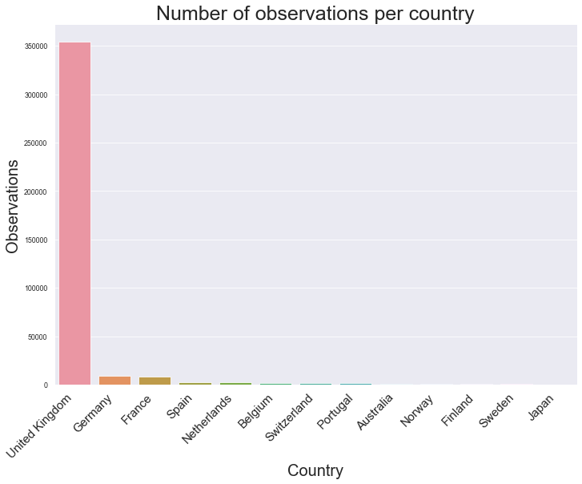

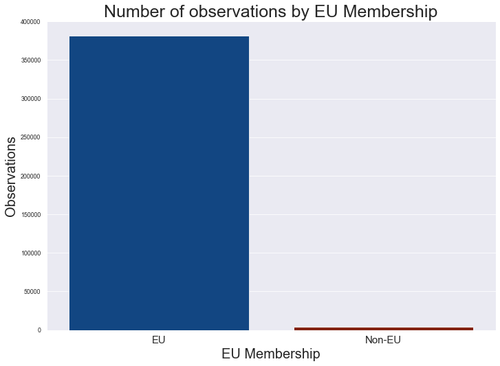

## 2.2. Number and total sales by country

As expected, the **UK** presents the **largest sales in terms of volume and aggregated unit price**. However, some markets are prone to buy larger quantities and other to spend more. For instance, we observe that **France** is the fourth in terms of number of sales, but second in terms of total sales.

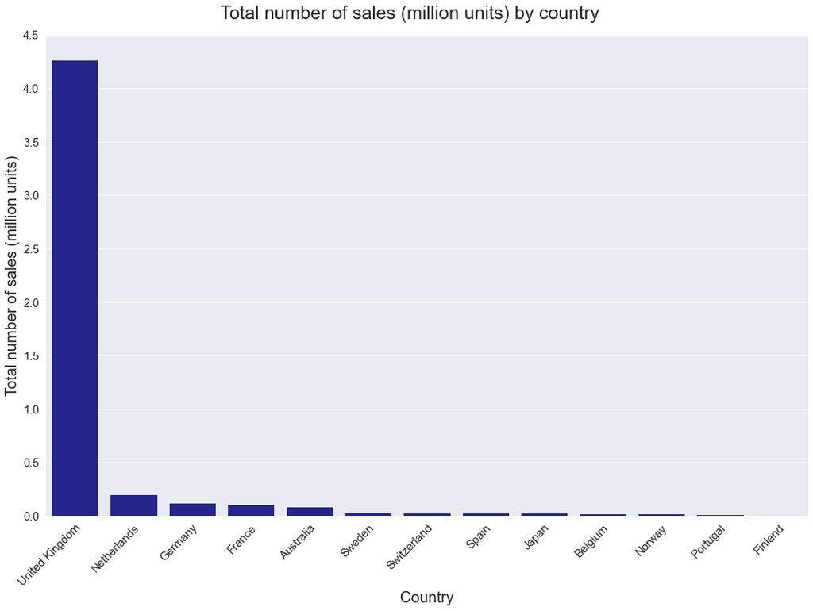

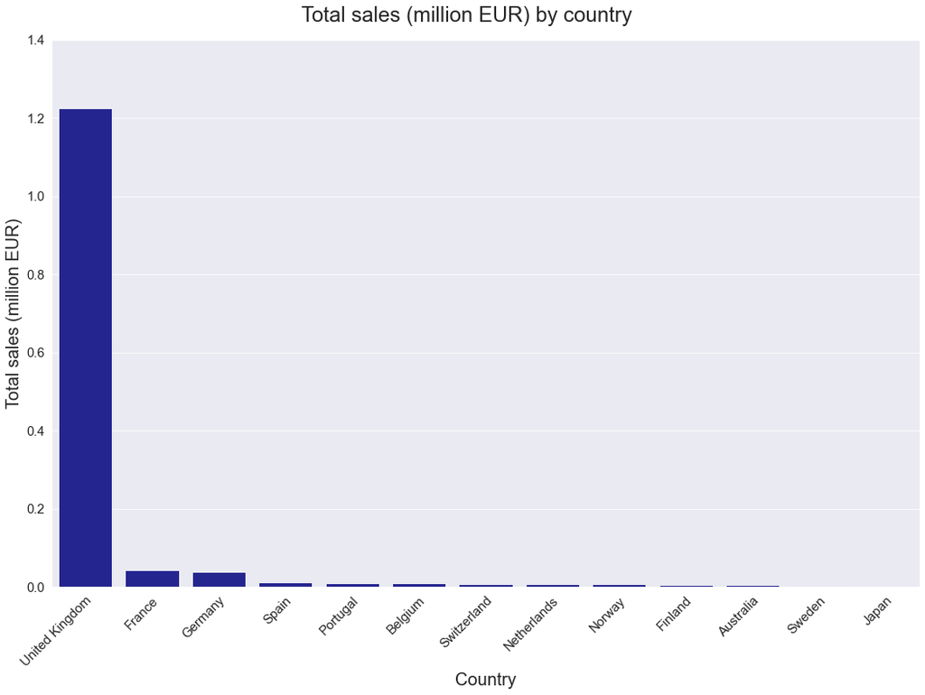

## 2.4. Unique customers by country

[figure not shown]

## Average item price by country

Despite being the largest market in all the previously analyzed KPIs, the UK is eleventh in terms of average item price. Surprisingly, **Portugal presents the highest average item price** while at the same time having the lowest GDP per capita.

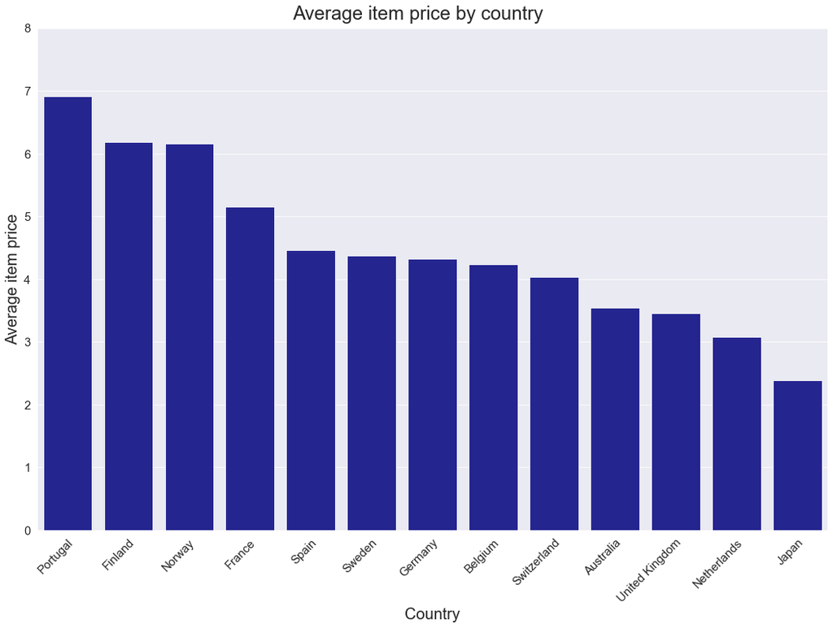

## 3. Market Analysis

## 3.1. Relationship between GDP and expenditure

Based on the findings of the EDA, we are interested in further exploring the relationship between GDP per capita and market behavior. We conduct a **linear regression analysis** on GDP per capita and average expenditure by customer. Furthermore, we split the analysis by type of sale. The graph below shows there seems to be a **positive relationship between the two in the segment "Wholesale"**, while it appears that no relationship exists for "Retail".

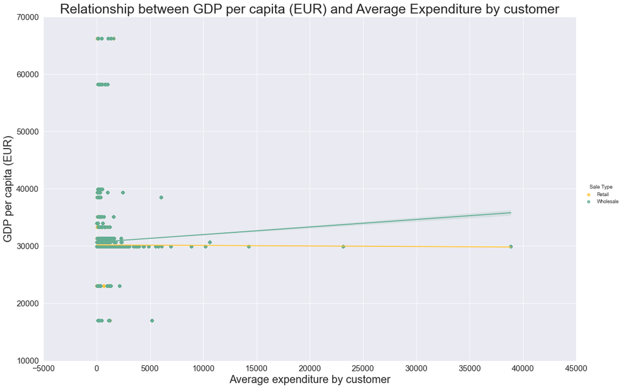

## 3.2. Quantity trends by type of sale

In this part of the analysis, we examine the **seasonality of sales** by segment and EU membership, focusing on quantity. For the segment "Retail" no clear peak can be identified neither in EU markets nor in non-EU markets. However, for non-EU markets there seems to be more variation, probably due to the size difference between the two samples.

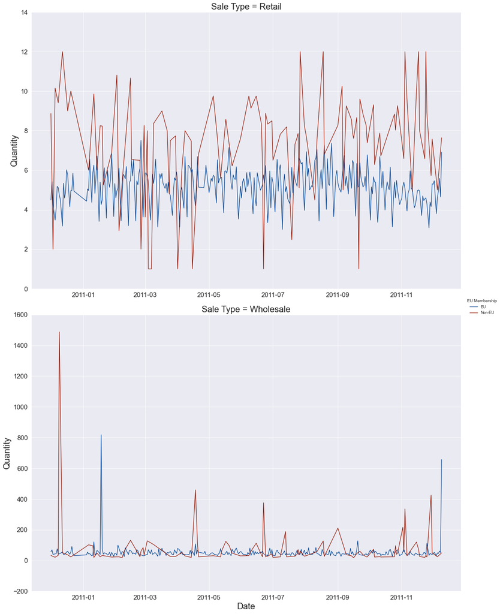

## 3.3. Price trends by type of sale

We then examine **item price trends**.

For **"Retail" no peak exists in EU markets**, while non-EU markets present two clear peaks. Considering the nature of the segment and the **magnitude of the abrupt change**, we should be careful when interpreting such results, as they might be originated by errors in data collection.

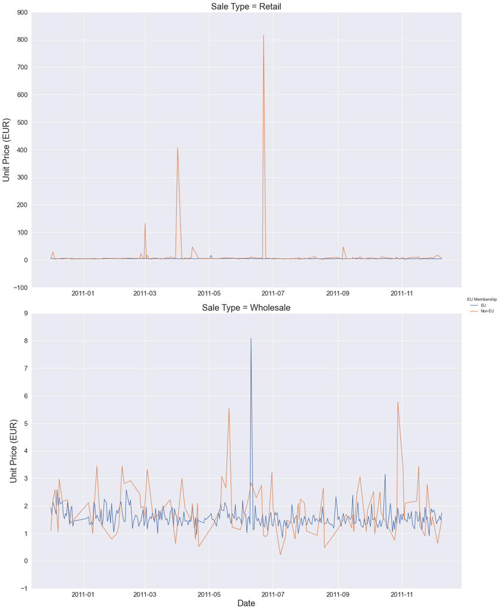

## 4. Product analysis

## 4.1. Most popular colors

In this part of the analysis we analize the **ten most popular colors** displayed below. For this purpose, we extracted from the column "Description" words referring to colors and merged the main data with the colors dataset, in order to display the frequency of each color by its corresponding hex code.

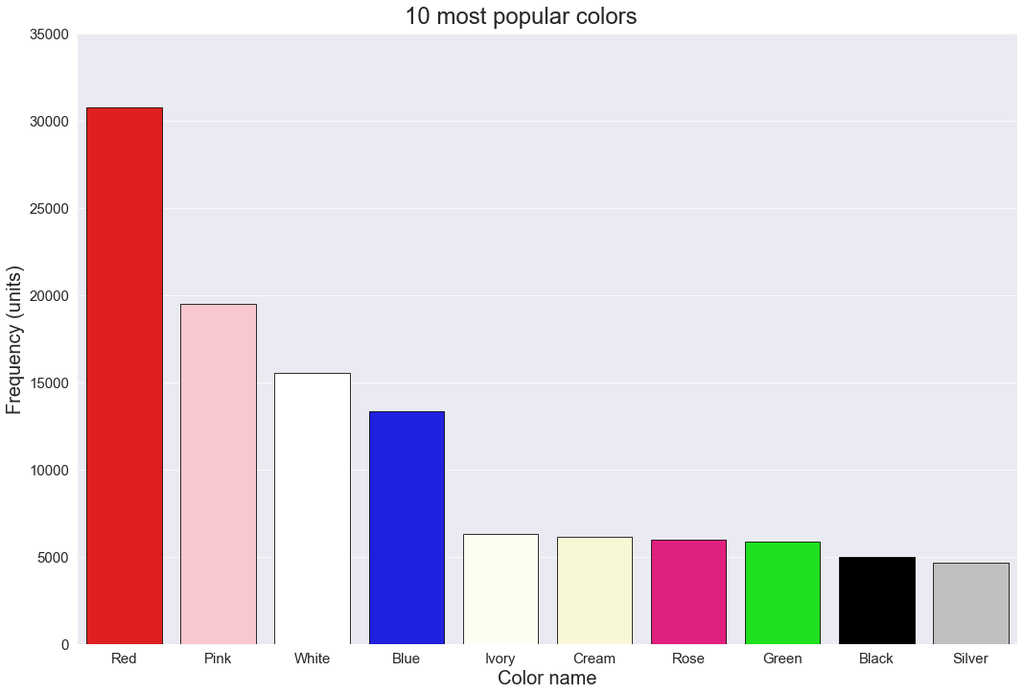

## 4.2. Most popular and most returned items

Comparing the two graph below, it can be observed that intuitively, **items that are ordered more frequently are also returned frequently**, for instance "Regency cakestand 3 tier".

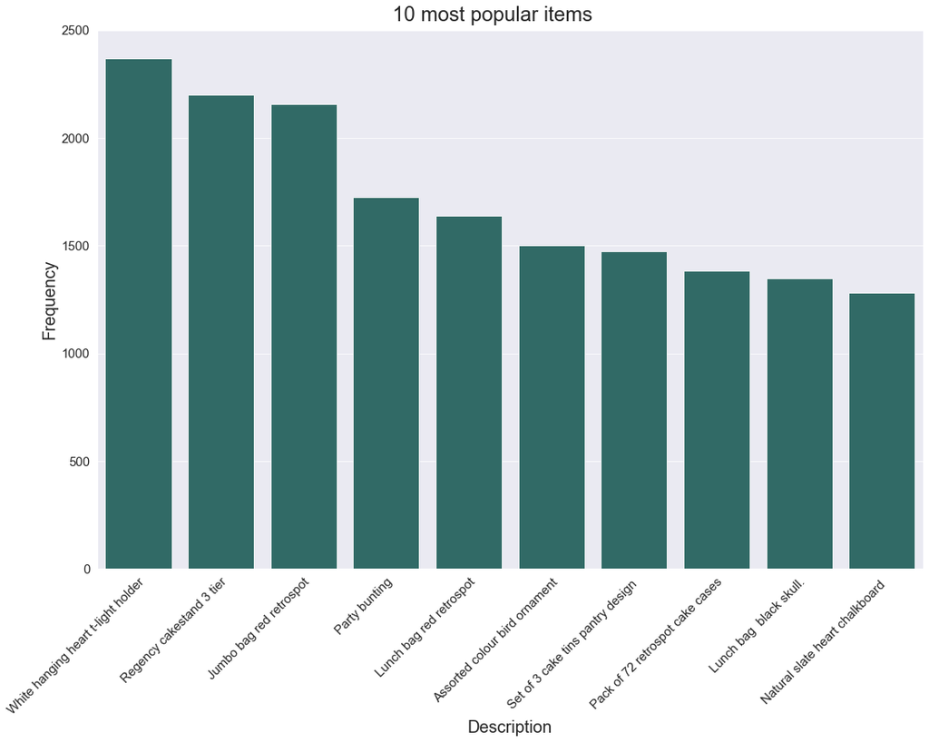

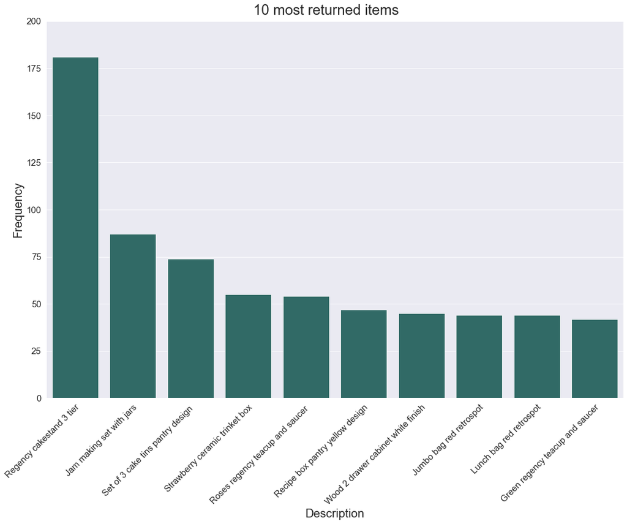

## 5. Conclusions

The **key results** from our analysis are:

- The **UK is largest market** in terms of total sales and number of sales.
- Considering the **observed customer behavior** in certain markets, such as Portugal, there are **growth opportunities**: in such markets customers tend to purchase more expensive items, however the number of sales is significantly smaller compared to other markets.
- The **positive relationship between GDP per capita and wholesale sales** represents a chance to **increase the sales volumes** in countries associated with higher GDP per capita, which currently are among the least relevant markets.
- **Seasonality trends** show that there is room to develop **tailor-made sales strategies** for each peak season.

```
[NbConvertApp] Converting notebook cust-proj.ipynb to html
```

```
0
```

```
[NbConvertApp] Writing 1830386 bytes to cust-proj.html
```